# Problema 3 - Chekcpoint 2

Luiza Carvalho

28 de junho de 2017

Nesta análise será feito um agrupamento de dados com múltiplas variáveis utilizando o algoritmo k-means, os dados que serão utilizados e separados em grupos saã sobre a quantidade de falas de personagens de diferentes gêneros em filmes de hollywood.

## Trabalhando os dados

Os conjuntos de dados brutos utilizados foram o das tabelas de personagens e filmes, que continham respectivamente tais variáveis:

```r
char <- read.csv('character_list5.csv')
names(char)
```

```
## [1] "script_id"           "imdb_character_name" "words"
## [4] "gender"              "age"
```

```r
filmes <- read.csv('meta_data7.csv')
names(filmes)
```

```
## [1] "script_id"  "imdb_id"    "title"      "year"       "gross"
## [6] "lines_data"
```

Estes dados foram combinados e modificados para obter o conjunto de dados que será utilizado nessa análise. O conjunto da nossa análise possui variáveis como o id do script do filme, o nome do filme, o número total de personagens femininas, o número total de falas femininas, o número total de personagens masculinos e o número total de falas masculinas.

```r
dados = filmes %>% left_join(char)
#Removendo colunas irrelevantes

dados <- dados[ -c(2, 5, 10) ]

# Criando o data frame apenas com as personagens femininas e adicionando as colunas necessarias
dados_f <- dados %>% filter(gender == 'f')

dados_f <- dados_f %>% group_by(title, gender) %>% mutate(countf = n())
dados_f <- dados_f %>% group_by(title) %>% mutate(wordsf = sum(words))

# Criando o data frame apenas com os personagens masculinos e adicionando as colunas necessarias

dados_m <- dados %>% filter(gender == 'm')
dados_m <- dados_m %>% group_by(title, gender) %>% mutate(countm = n())
dados_m <- dados_m %>% group_by(title) %>% mutate(wordsm = sum(words))

# Removendo colunas que nao serao utilizadas

dados_f <- dados_f[ -c(4:7)]
dados_m <- dados_m[ -c(4:7)]

# Juntando os dados parar criar o conjunto de dados final
dados <- dados_f %>% left_join(dados_m)
dados <- unique(dados)


# Renomeando as variaveis
names(dados)[names(dados)=="script_id"] <- "Id"
names(dados)[names(dados)=="title"] <- "Filme"
names(dados)[names(dados)=="year"] <- "Ano"
names(dados)[names(dados)=="wordsf"] <- "Palavras.Ditas.por.Mulheres"
names(dados)[names(dados)=="wordsm"] <- "Palavras.Ditas.por.Homens"
names(dados)[names(dados)=="countf"] <- "Numero.de.Mulheres"
names(dados)[names(dados)=="countm"] <- "Numero.de.Homens"

# Excluindo os NA
dados <- na.omit(dados)

names(dados)
```

```
## [1] "Id"                          "Filme"
## [3] "Ano"                         "Numero.de.Mulheres"
## [5] "Palavras.Ditas.por.Mulheres" "Numero.de.Homens"
## [7] "Palavras.Ditas.por.Homens"
```

Muitos dados, como por exemplo o nome individual de cada personagem, seu número individual de palavras e sua idade, foi descartado. Pois o intuito dessa análise é avaliar o panorama geral sobre a quantidade de falas por gênero dos personagens em filmes de hollywood ao decorrer dos anos, assim fazendo uso da quantidade total de falas e de personagens de cada gênero, portanto todos os dados que não remetiam a essas informações foram descartados.

## Panorama das Mulheres nos Filmes

Antes de começar o agrupamento vamos observar o panorama geral das mulheres em Hollyood. Faremos isso comparando o gráfico do número de mulheres em filmes por ano com o seu equivalente masculino.

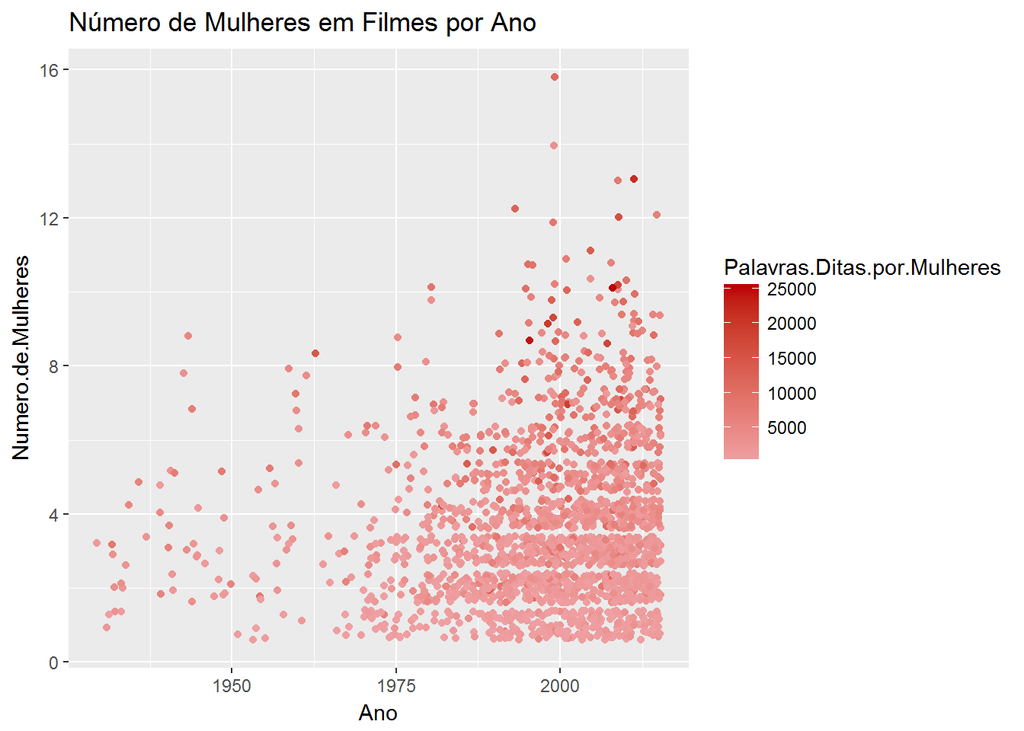

```r
ggplot(dados, aes(Ano,Numero.de.Mulheres, color = Palavras.Ditas.por.Mulheres, text = Filme)) + labs(title = "Número de Mulheres em Filmes por Ano") + geom_jitter() + scale_color_gradient(low="#efa0a3", high="#bc0007")
```

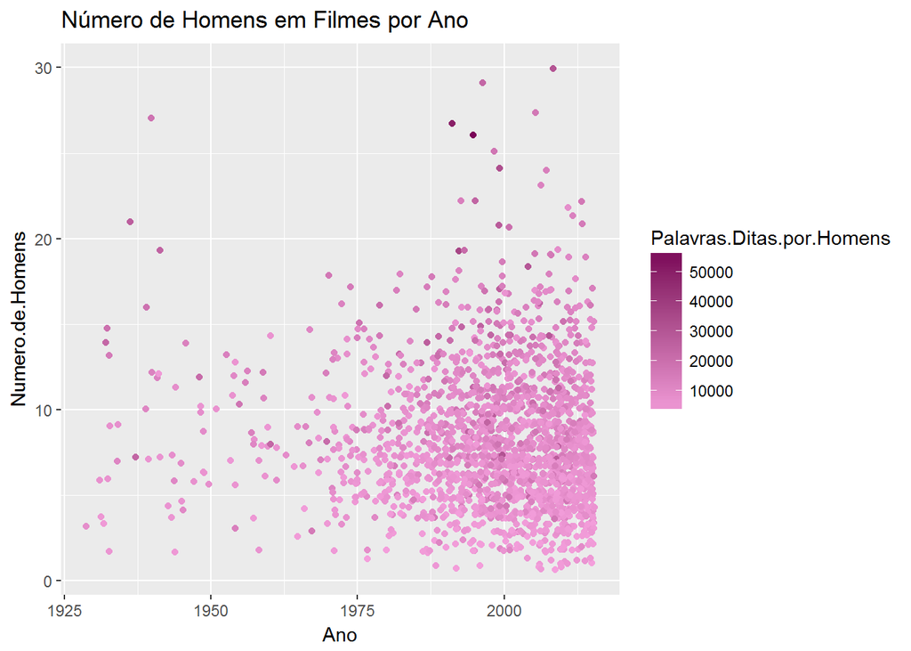

```r
ggplot(dados, aes(Ano,Numero.de.Homens, color = Palavras.Ditas.por.Homens, text = Filme)) + labs(title = "Número de Homens em Filmes por Ano") + geom_jitter() + scale_color_gradient(low="#f49fdc", high="#7a0258")
```

Observando os gráficos vemos que o número de homens em filmes tende a ser bem maior que o de mulheres, se concentrando na faixa de 5 a 15, enquanto para as mulheres 10 já é um número alto, elas se concentram na faixa de 1 a 5, estando a maioria dos filmes abaixo da linha de 6 mulheres.

Agora avaliaremos os gráficos referentes a mediana de mulheres em filmes por ano e a mediana das falas das mulheres nos filmes por ano:

```r
dados1 <- dados %>% group_by(Ano) %>% mutate(medianaM = median(as.numeric(Numero.de.Mulheres)), medianaH = median(as.numeric(Numero.de.Homens)), MedFalaM = median(as.numeric(Palavras.Ditas.por.Mulheres)), MedFalaH = median(as.numeric(Palavras.Ditas.por.Homens)) )

dados1 <- dados1[-c(1,2,4:7)]
dados1 <- unique(dados1)

p <- ggplot(dados1, aes(Ano, medianaM)) + labs(title = "Mediana do Número de Mulheres em Filmes por Ano") + geom_line(color = "#597db7") + labs(y = "Mediana de Personagens Mulheres")

p1 <- ggplot(dados1, aes(Ano,MedFalaM)) + labs(title = "Mediana do Número de Falas Femininas em Filmes por Ano") + geom_line(color = "#7dcadb") + labs(y = "Mediana de Falas Femininas")

ggplotly(p, width = 800, height = 500)
```

```
## We recommend that you use the dev version of ggplot2 with `ggplotly()`
## Install it with: `devtools::install_github('hadley/ggplot2')`
```

[interactive chart not shown]

```r
ggplotly(p1, width= 800, height = 500)
```

```
## We recommend that you use the dev version of ggplot2 with `ggplotly()`
## Install it with: `devtools::install_github('hadley/ggplot2')`
```

[interactive chart not shown]

Podemos observar que em ambos os casos não há um crescimento da participação feminina nos filmes. O número de mulheres costumava variar muito entre 1925 e 1985, a partir desse ano a variação diminuiu e a mediana de mulheres por filme começou a sempre se encontrar entre 2 e 4. Houveram picos de representatividade feminina (em números) nos anos 50, 60 e 63, esses picos foram refletidos no número de falas nos anos 50 e 63. Podemos observar também que o número de falas femininas vem caindo um pouco de 1932 para os dias atuais.